# Peer-graded Assignment: Course Project: Shiny Application and Reproducible Pitch

Maria Delgado

September 24, 2025

# The Challenge

The Iris dataset is a classic in Machine Learning.

*Goal:* Predict the species of a flower (Setosa, Versicolor, Virginica) using its measurements (sepals and petals).

*Central question:* Can we assign the correct species based only on 4 numerical variables?

# The Solution

1. We built three logistic regression models (one-vs-rest):
   - Model 1: Setosa vs. not-Setosa
   - Model 2: Versicolor vs. not-Versicolor
   - Model 3: Virginica vs. not-Virginica
2. Each model returns a probability of belonging to its species.
3. The final classification comes from the highest probability.

# How It Works

- Input variables:
  - Sepal.Length, Sepal.Width, Petal.Length, Petal.Width
- Logistic transformation: converts linear combinations into probabilities between 0 and 1.
- Intuitive interpretation:
  - Probability close to 1 → high certainty.
  - Probability close to 0 → low certainty.

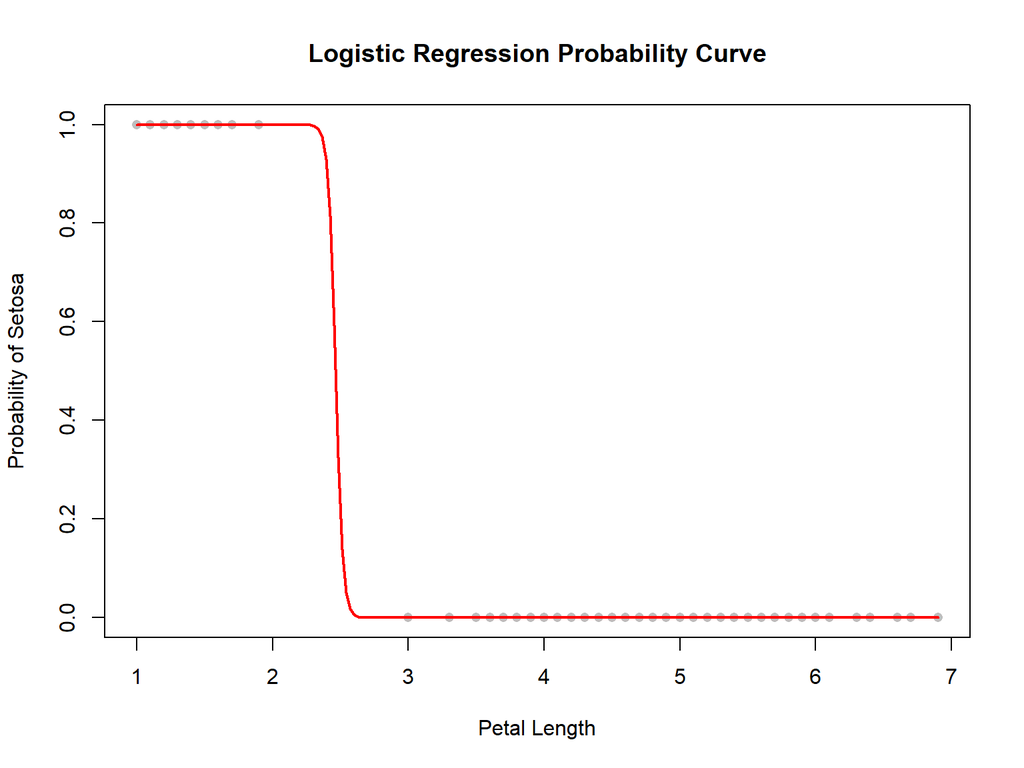

# Final Result

The Shinny app can be viewed visiting: https://madelgadolo.shinyapps.io/assignment3_madl/

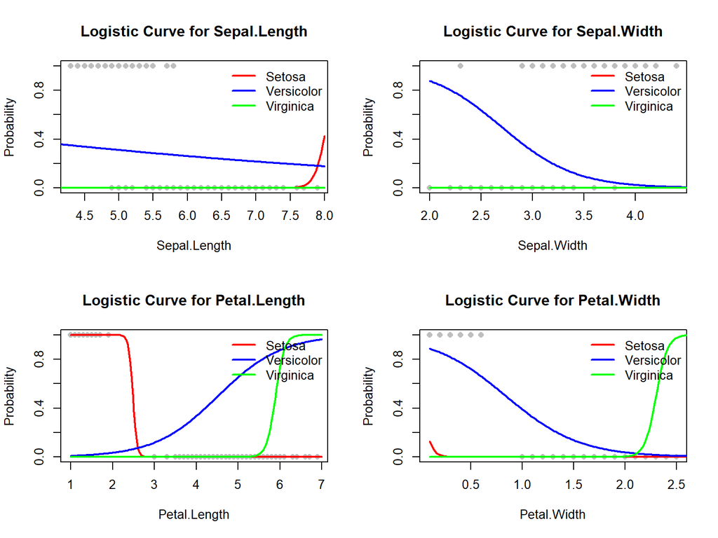